# **Bias-variance decomposition**

# Fixed-X prediction error

In the Fixed-X setting we have the training set
$$(x_1,y_1),\ldots,(x_n,y_n)$$
and the test set
$$(x_1,y^*_1),\ldots,(x_n,y^*_n)$$
where

- the training values $x_1,\ldots,x_n$ are treated as fixed (i.e. non-random)
- the test values exactly match the the training values

In matrix notation we have

- Vector of response:
  $$\underset{n\times 1}{\mathbf{y}} =
  \left[
  \begin{array}{c}
  y_1 \\
  \cdots\\
  y_i \\
  \cdots\\
  y_n \\
  \end{array}\right], \qquad \underset{n\times 1}{\mathbf{y}^*} =
  \left[
  \begin{array}{c}
  y^*_1 \\
  \cdots\\
  y^*_i \\
  \cdots\\
  y^*_n \\
  \end{array}\right]$$
- Design matrix:
  $$\underset{n\times p}{\mathbf{X}} = \left[
  \begin{array}{cccccc}
  x_{1}^\mathsf{T} \\
  x_{2}^\mathsf{T} \\
  \cdots \\
  x_{i}^\mathsf{T} \\
  \cdots\\
  x_{n}^\mathsf{T}\\
  \end{array}\right] = \left[
  \begin{array}{cccccc}
  x_{11} & x_{12} & \cdots & x_{1j} & \cdots & x_{1p} \\
  x_{21} & x_{22} & \cdots & x_{2j} & \cdots & x_{2p} \\
  \cdots & \cdots & \cdots & \cdots & \cdots \\
  x_{i1} & x_{i2} & \cdots & x_{ij}& \cdots & x_{ip} \\
  \cdots & \cdots & \cdots & \cdots & \cdots\\
  x_{n1} & x_{n2} & \cdots & x_{nj} & \cdots & x_{np}\\
  \end{array}\right]$$

The responses $y_1, \ldots, y_n$ are realizations of the random variables
$$Y_i = f(x_i)+ \varepsilon_i, \quad i=1,\ldots,n$$
and $y^*_1, \ldots, y^*_n$ are realizations of the random variables
$$Y^*_{i}=f(x_i)+\varepsilon^*_i, \quad i=1,\ldots,n$$
where $f$ is called the **regression function** and $\varepsilon_1,\ldots,\varepsilon_n$ and $\varepsilon^*_1,\ldots,\varepsilon^*_n$ are i.i.d. with $\mathbb{E}(\varepsilon)=0$ and $\mathbb{V}\mathrm{ar}(\varepsilon)=\sigma^2$.

In the fixed-X setting, the **prediction error** $\mathrm{ErrF}$ is defined by
$$\mathrm{ErrF} = \mathbb{E}(\mathrm{MSE}_{\mathrm{Te}})=\mathbb{E}\left[\frac{1}{n}\sum_{i=1}^{n}( Y^*_i - \hat{f}(x_i))^2\right]= \frac{1}{n}\sum_{i=1}^{n}\mathbb{E}\left[( Y^*_i - \hat{f}(x_i))^2\right]$$

# Bias-variance decomposition

We start by considering a specific value $x_i$ for $x$. Suppose we want to predict $y^*_i$ by $\hat{y}_i^* = \hat{f}(x_i)$ where $\hat{f}$ is an estimate of $f$ based on the training data. The accuracy of $\hat{y}^*_i$ as a prediction for $y^*_i$ depends on two quantities, which we call the **reducible error** and the **irreducible error**. We have
$$\mathbb{E}[(Y^*_{i} - \hat{Y}^*_i)^2] = \mathbb{E}[(f(x_i) + \varepsilon^*_i - \hat{f}(x_i))^2] = \underbrace{\mathbb{E}[(f(x_i) - \hat{f}(x_i))^2]}_{\mathrm{Reducible}} + \underbrace{\mathbb{V}\mathrm{ar}(\varepsilon^*_i)}_{\mathrm{Irreducible}}$$

where $\mathbb{V}\mathrm{ar}(\varepsilon^*_i) = \sigma^2$. Note that, even if it were possible to form a perfect estimate for $f$, so that our estimated response took the form $\hat{y}^*_i = f(x_i)$, our prediction would still have some error in it. This is because $Y_i^* = f(x_i) + \varepsilon_i^*$.

The reducible error can be decomposed into (squared) **bias** and **variance** of the estimator $\hat{f}$, respectively:
$$\mathbb{E}[(f(x_i) - \hat{f}(x_i))^2] = \mathbb{E}[(f(x_i) - \mathbb{E}\hat{f}(x_i) + \mathbb{E}\hat{f}(x_i) - \hat{f}(x_i))^2] =
\underbrace{ [\mathbb{E}\hat{f}(x_i) - f(x_i) ]^2}_{[\mathrm{Bias}(\hat{f}(x_i))]^2} + \underbrace{\mathbb{V}\mathrm{ar}[\hat{f}(x_i)]}_{\mathrm{Variance}(\hat{f}(x_i))}$$

Now the decomposition of fixed-X prediction error is simply

$$\mathrm{ErrF} = \sigma^2 + \underbrace{\frac{1}{n}\sum_{i=1}^{n}(\mathbb{E}\hat{f}(x_i) - f(x_i) )^2}_{\mathrm{Bias}^2} + \underbrace{\frac{1}{n}\sum_{i=1}^{n} \mathbb{V}\mathrm{ar}(\hat{f}(x_i))}_{\mathrm{Variance}} = \sigma^2 + [\mathrm{Bias}(\hat{f})]^2+\mathrm{Variance}(\hat{f})$$

Bias and variance are conflicting entities, and we cannot minimize both simultaneously. We must therefore choose a **trade-off** between bias and variance.

# Simulation

For the yesterday-tomorrow data, the true $f(x)$ is

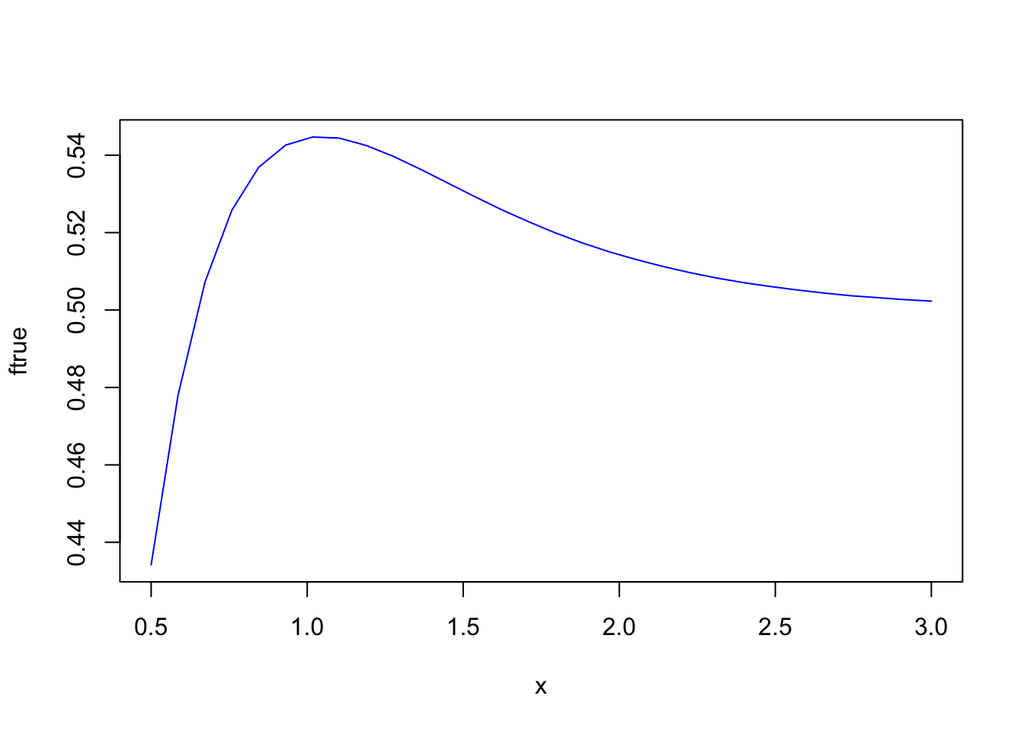

```r
# true regression function
ftrue <- c(0.4342,0.4780,0.5072,0.5258,0.5369,0.5426,0.5447,0.5444,0.5425,0.5397,0.5364,0.5329,0.5294,0.5260,0.5229,0.5200,0.5174,0.5151,0.5131,0.5113,0.5097,0.5083,0.5071,0.5061,0.5052,0.5044,0.5037,0.5032,0.5027,0.5023)
x = seq(.5,3,length=30)
plot(x,ftrue, type="l", col=4)
```

Consider the polynomial regression of degree $d$. We will perform a simulation to compute squared bias $[\mathbb{E}\hat{f}(x_i) - f(x_i) ]^2$ and variance $\mathbb{V}\mathrm{ar}[\hat{f}(x_i)]$.

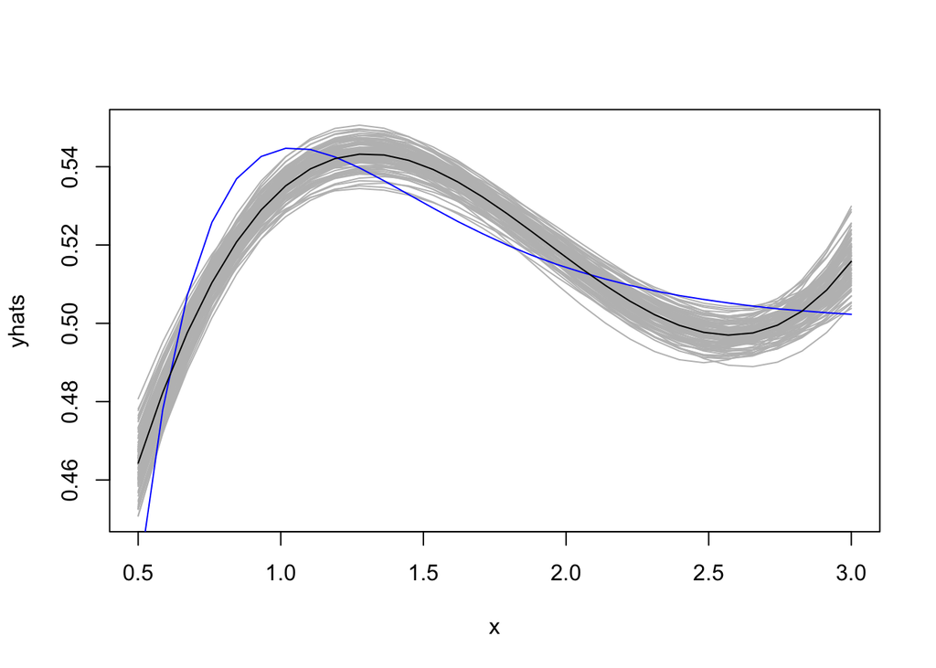

```r
# setting
sigmatrue=0.01
n = length(x)
d = 3
p = d+1
B = 100
# simulation function
sim = function(d){
y = ftrue + rnorm(n,0,sigmatrue)
fit = lm(y ~ poly(x,degree=d))
yhat = fitted(fit)
}
# results
set.seed(123)
yhats = replicate(B,sim(d))
matplot(x,yhats, type="l", col="gray", lty=1)
lines(x,ftrue, col=4)
# expected value
Ave = apply(yhats,1,mean)
lines(x,Ave)
```

```r
# squared bias
Bias2 = (ftrue - Ave)^2
# variance
Var = apply(yhats,1,var)
```

The bias-variance decomposition gives

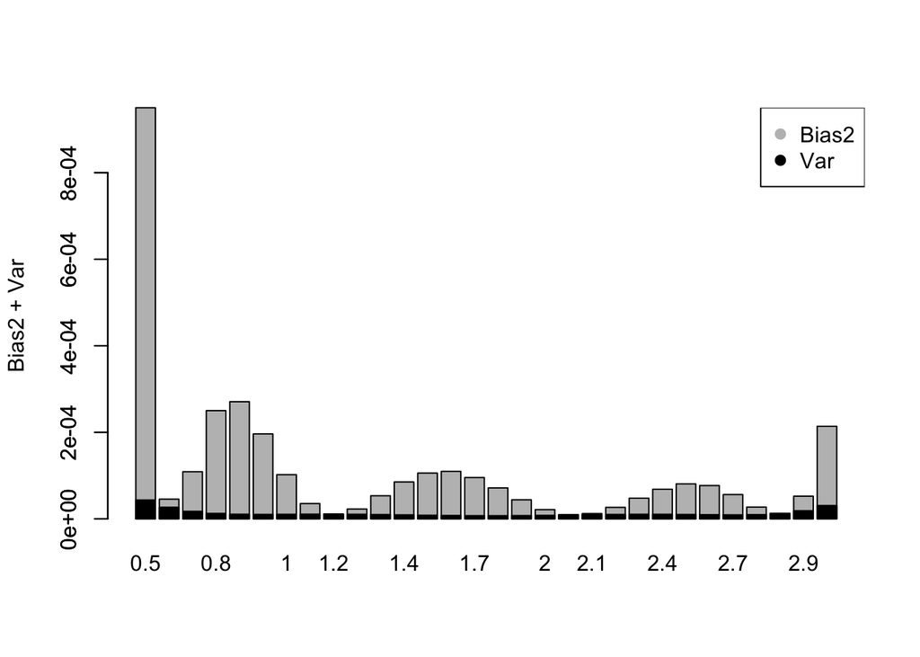

```r
barplot(Bias2+Var, ylab="Bias2 + Var", names.arg=round(x,1))
barplot(Var,add=T, col=1, names.arg=" ")
legend("topright", c("Bias2","Var"), col=c("gray",1), pch=c(19,19))
```

Note that the expected value $\mathbb{E}\hat{f}(x_i)$ can be obtained by fitting the polynomial model using $y_i = f(x_i)$. This allows to compute the squared bias $[\mathrm{Bias}(\hat{f})]^2= \frac{1}{n}\sum_{i=1}^{n}(\mathbb{E}\hat{f}(x_i) - f(x_i) )^2$.

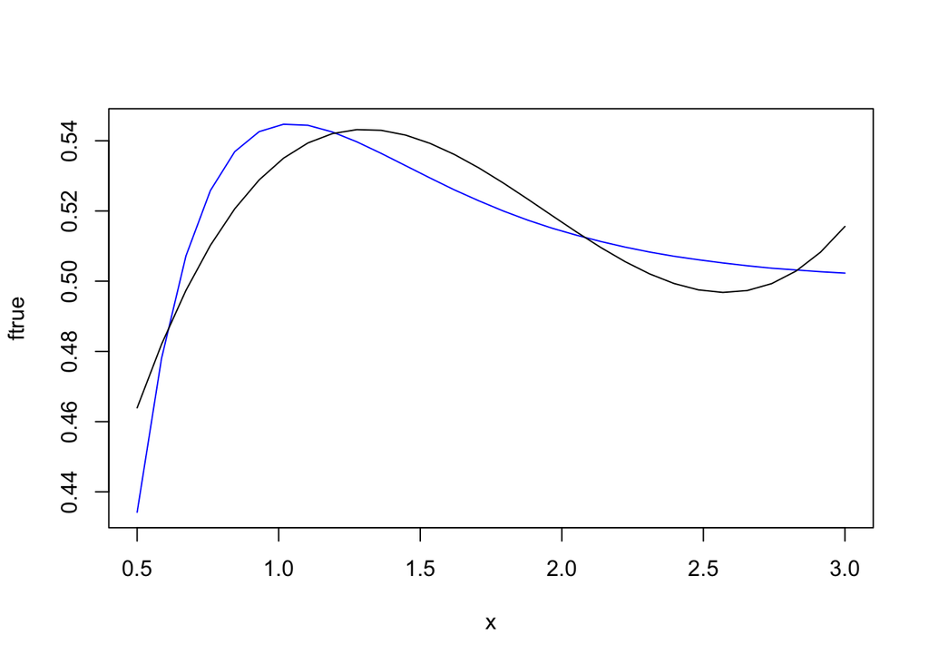

```r
# expected value
Ehatf = fitted(lm(ftrue ~ poly(x,degree=d)))
plot(x,ftrue, type="l", col=4)
lines(x,Ehatf)
```

```r
Bias2 = mean( (ftrue - Ehatf)^2 )
```

Theoretical results show that for the linear model
$$\frac{1}{n}\sum_{i=1}^{n}\mathbb{V}\mathrm{ar}[\hat{f}(x_i)] = \frac{\sigma^2 p}{n}$$
Importantly, in the linear model the variance is unaffected by the form of $f(x)$.

```r
# empirical variance
mean(Var)
```

```
[1] 1.265525e-05
```

```r
# true variance
(sigmatrue^2)*p/n
```

```
[1] 1.333333e-05
```

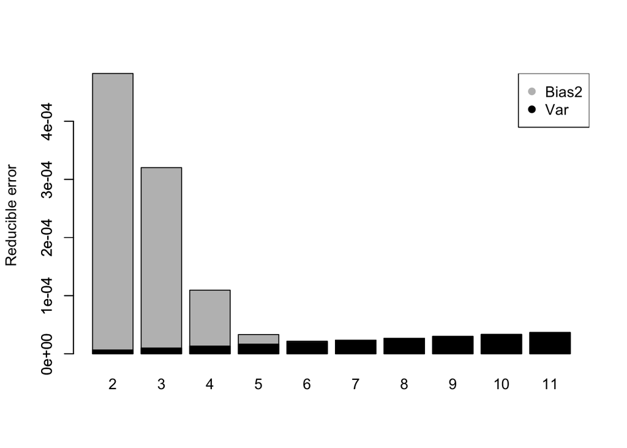

```r
ds = 1:10
ps = ds+1

Bias2s = sapply(ps, function(p)
  mean( ( ftrue - fitted(lm(ftrue ~ poly(x,degree=(p-1)))) )^2 )
  )
Vars = ps*(sigmatrue^2)/n
Reds = Bias2s+Vars
barplot(Reds, ylab="Reducible error", names.arg=ps)
barplot(Vars, add=T, col=1, names.arg=" ")
legend("topright", c("Bias2","Var"), col=c("gray",1), pch=c(19,19))
```

```r
# best model size
ps[which.min(Reds)]
```

```
[1] 6
```

The decomposition of the prediction error into irredubile and reducible error:

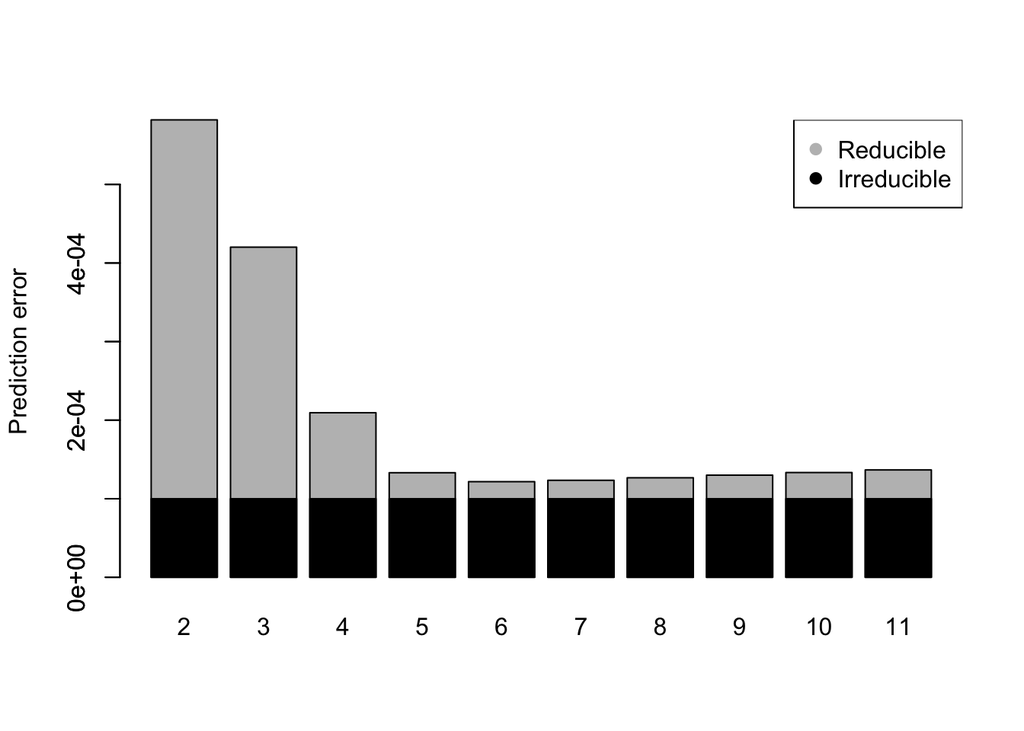

```r
# prediction error
Irr = rep(sigmatrue^2,length(ps))
ErrFs = Reds + Irr
barplot(ErrFs, ylab="Prediction error", names.arg=ps)
barplot(Irr, add=T, col=1, names.arg=" ")
legend("topright", c("Reducible","Irreducible"), col=c("gray",1), pch=c(19,19))
```

Now we chack the correctness of our results by comparing the empirical prediction error (calculated by simulation) and the theoretical prediction error (calculated by formulas).

```r
sigmatrue=0.01
n = length(x)
B = 1000
# simulation function
sim2 = function(d){
y = ftrue + rnorm(n,0,sigmatrue)
fit = lm(y ~ poly(x,degree=d))
yhat = fitted(fit)
ystar = ftrue + rnorm(n,0,sigmatrue)
MSE.te = mean((ystar - yhat)^2)
}
# MSE.te empirical
d = 5
mean(replicate(B,sim2(d)))
```

```
[1] 0.0001222711
```

```r
# MSE.te theoretical
Ehatf = fitted(lm(ftrue ~ poly(x,degree=d)))
Bias2 = mean( (ftrue - Ehatf)^2 )
p = d+1
Var = (sigmatrue^2)*p/n
Bias2 + Var + sigmatrue^2
```

```
[1] 0.0001217199
```